# Twitter Analysis

Tony

Sun Oct 01 16:13:43 2017

# Introduction

This report compares the volume, behavior, and content of the tweets made by Andrew and Tony.

```
## # A tibble: 2 x 2
##   person     n
##    <chr> <int>
## 1 Andrew  3164
## 2   Tony   519
## # A tibble: 2 x 2
##   person           timestamp
##    <chr>              <dttm>
## 1 Andrew 2014-09-23 17:23:37
## 2   Tony 2015-08-19 15:06:32
```

3164 have been collected for Andrew. 519 have been collected for Tony. Note that the oldest tweet made by Andrew (in the collected data) is from 2014-09-23 17:23:37 and the oldest tweet from Tony is from 2015-08-19 15:06:32.

# Tweet Volume

How often do Andrew and Tony tweet? Does the volume of tweets look different for temporal periods (e.g. year, month, etc.)?

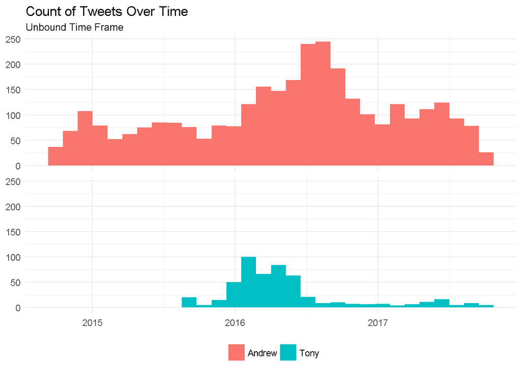

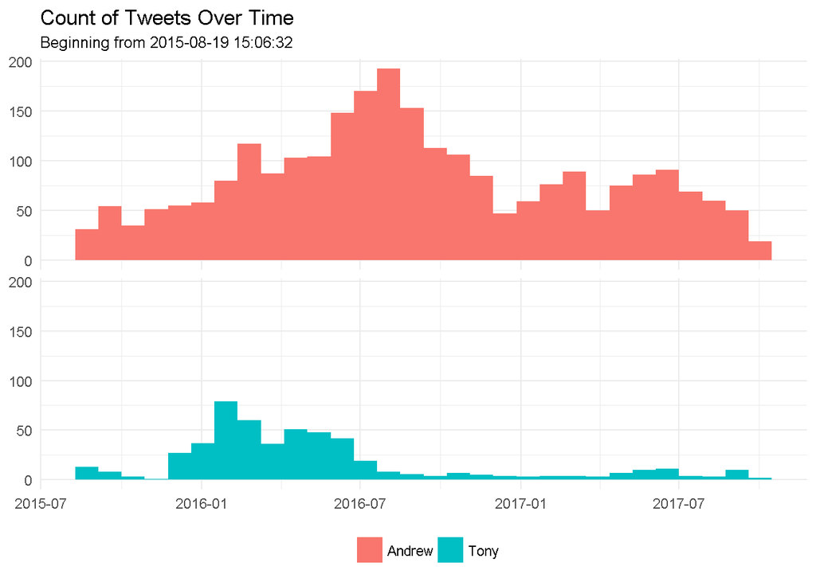

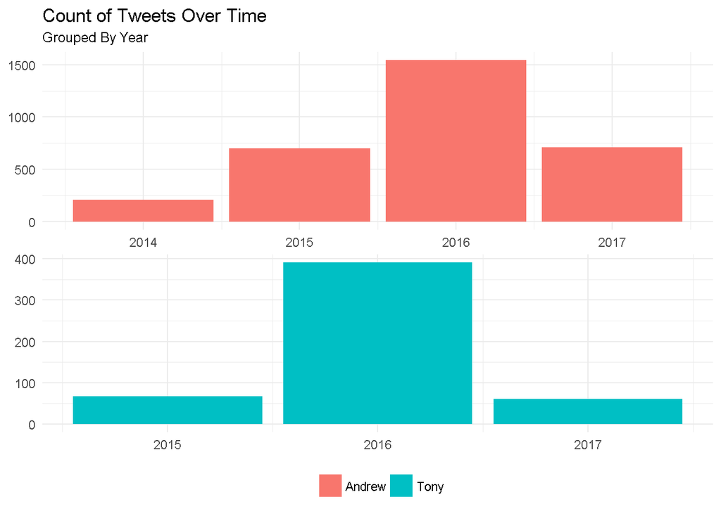

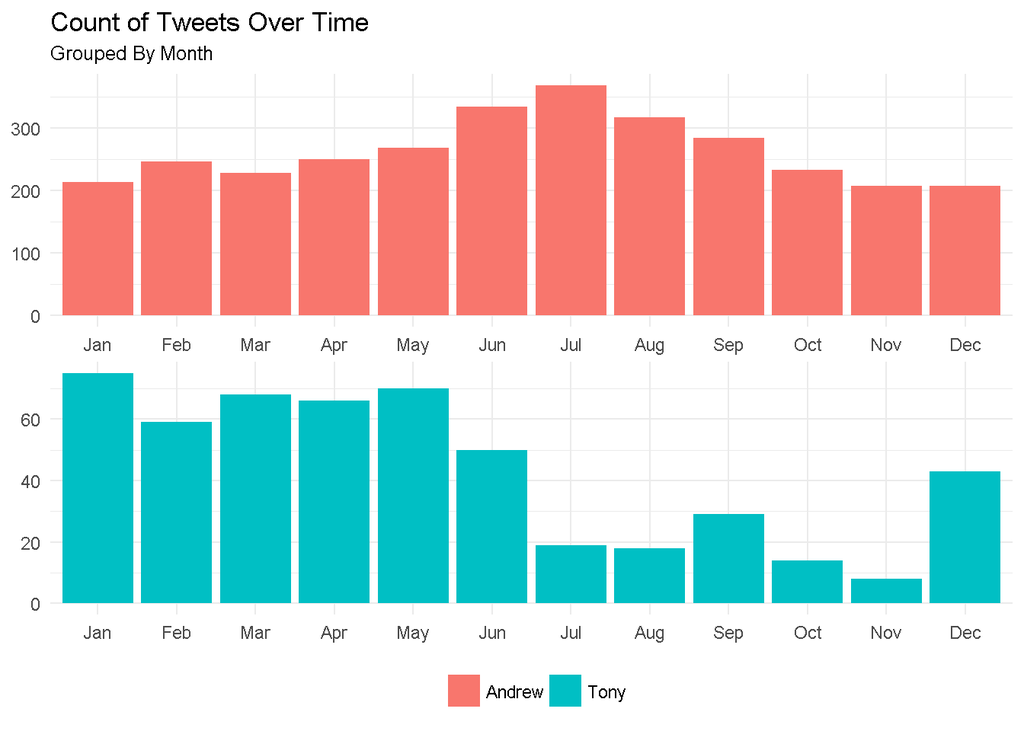

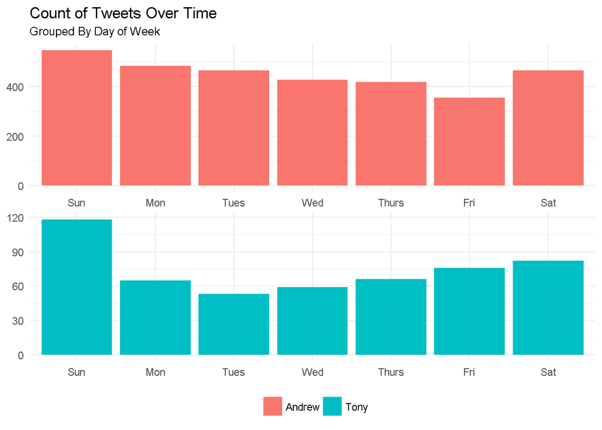

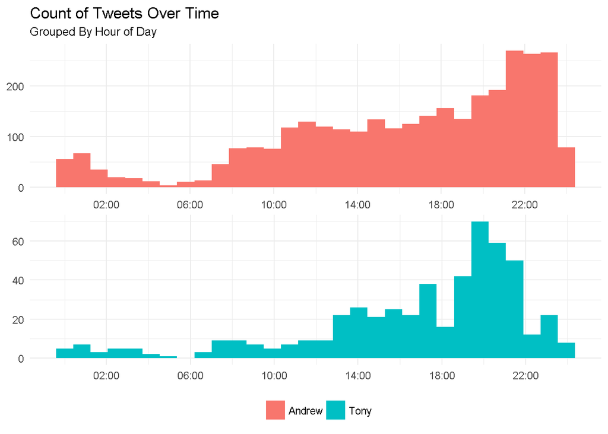

Is the distribution of our volume of tweets given a certain temporal period statistically significant? Here, I use the Chi-Squared Test. If the p-value is calculated to be less thatn some threshold value (e.g. 0.05), then I can deduce that the the null hypothes (that the distribution is uniform) is invalid. In fact, it appears that our tweet volume does differ depending on the month and day of the week.

```
##
##  Chi-squared test for given probabilities
##
## data:  .
## X-squared = 116.75, df = 11, p-value < 2.2e-16
##
##
##  Chi-squared test for given probabilities
##
## data:  .
## X-squared = 154.32, df = 11, p-value < 2.2e-16
##
##
##  Chi-squared test for given probabilities
##
## data:  .
## X-squared = 48.031, df = 6, p-value = 1.165e-08
##
##
##  Chi-squared test for given probabilities
##
## data:  .
## X-squared = 37.965, df = 6, p-value = 1.141e-06
##
## [1] 0.9859181
## [1] 0.6603261
##
##  Chi-squared test for given probabilities
##
## data:  .
## X-squared = 47.579, df = 6, p-value = 1.434e-08
##
##
##  Chi-squared test for given probabilities
##
## data:  .
## X-squared = 13.008, df = 6, p-value = 0.04292
```

# Tweet Behavior

How often do we use hashtags, RT, and reply?

```
## # A tibble: 24 x 4
##    person     type response  value
##  *  <chr>    <chr>    <chr>  <dbl>
##  1 Andrew  hashtag      yes 0.0553
##  2   Tony  hashtag      yes 0.0539
##  3 Andrew hashtag2      yes 0.0531
##  4   Tony hashtag2      yes 0.0539
##  5 Andrew  hashtag       no 0.9447
##  6   Tony  hashtag       no 0.9461
##  7 Andrew hashtag2       no 0.9469
##  8   Tony hashtag2       no 0.9461
##  9 Andrew     link      yes 0.3666
## 10   Tony     link      yes 0.4586
## # ... with 14 more rows
```

# Tweet Content

How Long are our tweets/

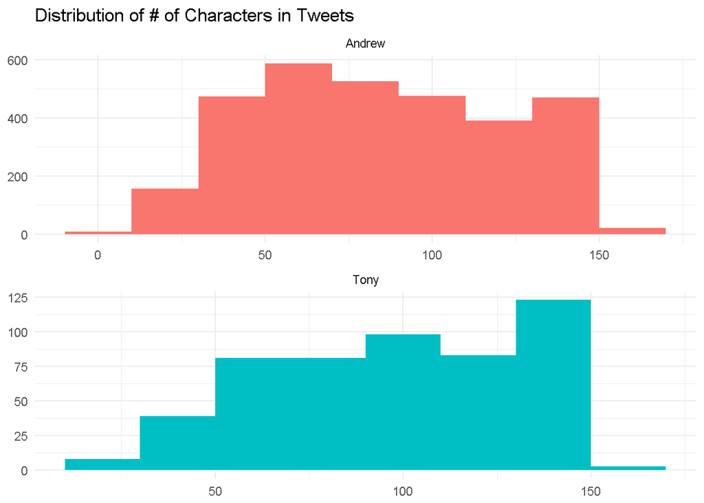

```
## # A tibble: 1 x 3
##   char_count_count char_count_avg char_count_max
##              <int>          <dbl>          <dbl>
## 1               60         344.85           3542
```

## Word Frequency and Usage

Which words are we most likely to use?

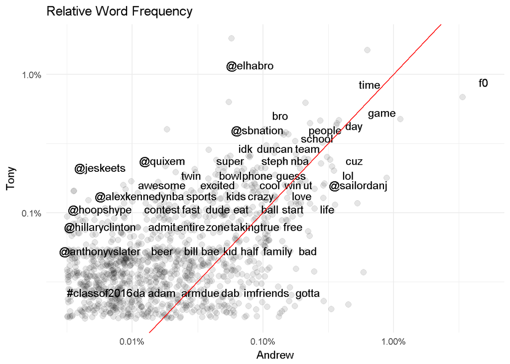

```
## # A tibble: 1,538 x 3
##    screen_name  word          created_at
##          <chr> <chr>               <chr>
##  1     elhabro  00a8 2016-04-01 14:56:28
##  2  TonyElHabr  00a8 2015-12-22 03:19:00
##  3  TonyElHabr  00a8 2015-12-22 03:19:00
##  4     elhabro  00a5 2016-04-01 14:56:28
##  5     elhabro  00a5 2016-04-03 02:56:22
##  6     elhabro  00a5 2016-04-03 02:56:22
##  7     elhabro  00a5 2016-04-03 02:56:22
##  8     elhabro  00a5 2016-04-03 02:56:22
##  9     elhabro  00a5 2016-04-03 18:23:27
## 10     elhabro  00a5 2016-04-06 23:48:42
## # ... with 1,528 more rows
## # A tibble: 2 x 2
##   person total
##    <chr> <int>
## 1 Andrew 17701
## 2   Tony  3283
## # A tibble: 8,121 x 5
## # Groups:   person [2]
##    person            word     n total        freq
##     <chr>           <chr> <int> <int>       <dbl>
##  1 Andrew              f0   862 17701 0.048697814
##  2 Andrew            game   145 17701 0.008191628
##  3 Andrew            time   116 17701 0.006553302
##  4 Andrew     @sailordanj    95 17701 0.005366928
##  5 Andrew             cuz    89 17701 0.005027965
##  6 Andrew             day    88 17701 0.004971471
##  7 Andrew             lol    79 17701 0.004463025
##  8 Andrew @dragonflyjonez    73 17701 0.004124061
##  9 Andrew           gonna    73 17701 0.004124061
## 10 Andrew            haha    67 17701 0.003785097
## # ... with 8,111 more rows
## # A tibble: 6,922 x 3
##               word       Andrew         Tony
##              <chr>        <dbl>        <dbl>
##  1    #classof2016 5.649398e-05 0.0003045995
##  2      #finalfour 5.649398e-05 0.0003045995
##  3     #graduation 5.649398e-05 0.0003045995
##  4   #marchmadness 5.649398e-05 0.0003045995
##  5         #rstats 5.649398e-05 0.0003045995
##  6 @alisongriswold 5.649398e-05 0.0003045995
##  7 @basketballtalk 5.649398e-05 0.0003045995
##  8  @bill_easterly 5.649398e-05 0.0003045995
##  9 @chldishricardo 5.649398e-05 0.0003045995
## 10 @coliegestudent 5.649398e-05 0.0003045995
## # ... with 6,912 more rows
```

Which words are most likely to be shared/different between us?

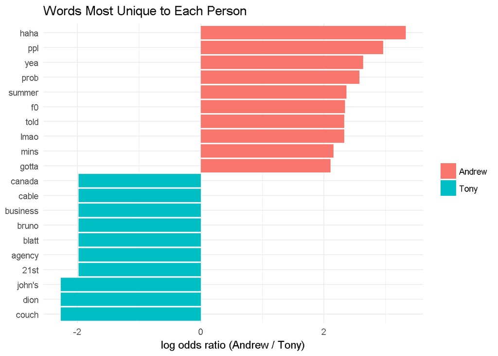

```
## # A tibble: 5,858 x 4
##      word       Andrew         Tony logratio
##     <chr>        <dbl>        <dbl>    <dbl>
##  1   haha 0.0031969911 0.0001141944 3.332063
##  2    ppl 0.0022096850 0.0001141944 2.962703
##  3    yea 0.0015984955 0.0001141944 2.638916
##  4   prob 0.0015044664 0.0001141944 2.578292
##  5 summer 0.0012223789 0.0001141944 2.370652
##  6     f0 0.0405735778 0.0038826082 2.346610
##  7   lmao 0.0023507287 0.0002283887 2.331432
##  8   told 0.0011753644 0.0001141944 2.331432
##  9   mins 0.0009873061 0.0001141944 2.157078
## 10  gotta 0.0018805830 0.0002283887 2.108288
## # ... with 5,848 more rows
## # A tibble: 5,858 x 4
```

[output cut: 27 more lines]

Which words have we used more/less frequently over time?

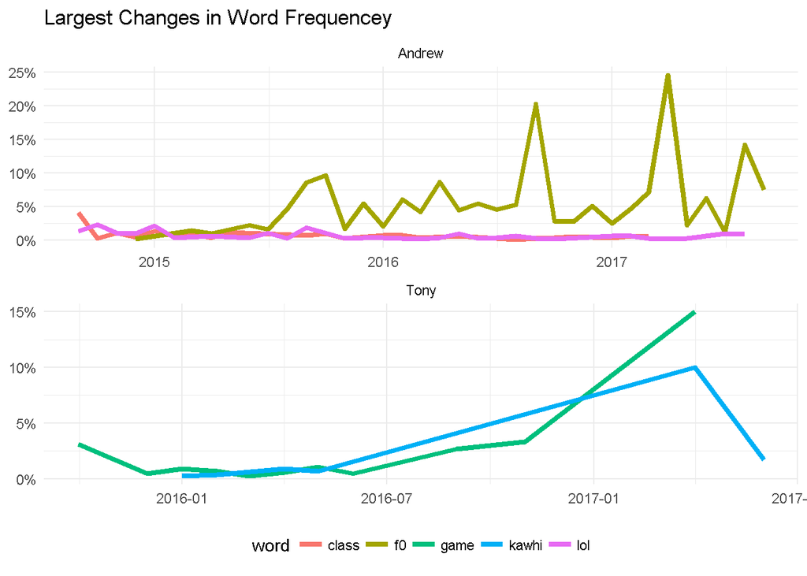

```
## # A tibble: 1,382 x 6
##    time_floor person    word count time_total word_total
##        <dttm>  <chr>   <chr> <int>      <int>      <int>
##  1 2014-09-01 Andrew     bad     1         73         41
##  2 2014-09-01 Andrew   class     3         73         59
##  3 2014-09-01 Andrew   gonna     1         73         77
##  4 2014-09-01 Andrew   guess     2         73         36
##  5 2014-09-01 Andrew   hours     1         73         40
##  6 2014-09-01 Andrew     lol     1         73         86
##  7 2014-09-01 Andrew   start     1         73         34
##  8 2014-09-01 Andrew twitter     1         73         49
##  9 2014-09-01 Andrew    week     1         73         50
## 10 2014-10-01 Andrew     bro     1        350         43
## # ... with 1,372 more rows
## # A tibble: 102 x 3
##    person    word              data
##     <chr>   <chr>            <list>
##  1 Andrew     bad <tibble [27 x 4]>
##  2 Andrew   class <tibble [24 x 4]>
##  3 Andrew   gonna <tibble [32 x 4]>
##  4 Andrew   guess <tibble [22 x 4]>
##  5 Andrew   hours <tibble [22 x 4]>
##  6 Andrew     lol <tibble [29 x 4]>
##  7 Andrew   start <tibble [22 x 4]>
##  8 Andrew twitter <tibble [20 x 4]>
##  9 Andrew    week <tibble [26 x 4]>
## 10 Andrew     bro <tibble [14 x 4]>
## # ... with 92 more rows
## # A tibble: 102 x 4
##    person    word              data    models
##     <chr>   <chr>            <list>    <list>
##  1 Andrew     bad <tibble [27 x 4]> <S3: glm>
##  2 Andrew   class <tibble [24 x 4]> <S3: glm>
##  3 Andrew   gonna <tibble [32 x 4]> <S3: glm>
##  4 Andrew   guess <tibble [22 x 4]> <S3: glm>
##  5 Andrew   hours <tibble [22 x 4]> <S3: glm>
##  6 Andrew     lol <tibble [29 x 4]> <S3: glm>
##  7 Andrew   start <tibble [22 x 4]> <S3: glm>
##  8 Andrew twitter <tibble [20 x 4]> <S3: glm>
##  9 Andrew    week <tibble [26 x 4]> <S3: glm>
## 10 Andrew     bro <tibble [14 x 4]> <S3: glm>
## # ... with 92 more rows
## # A tibble: 5 x 8
##   person  word       term      estimate    std.error statistic
##    <chr> <chr>      <chr>         <dbl>        <dbl>     <dbl>
## 1 Andrew    f0 time_floor  1.643854e-08 1.730128e-09  9.501347
## 2 Andrew   lol time_floor -1.625020e-08 4.422427e-09 -3.674498
## 3   Tony  game time_floor  7.449339e-08 2.036544e-08  3.657834
## 4   Tony kawhi time_floor  5.225945e-08 1.808690e-08  2.889354
## 5 Andrew class time_floor -1.561842e-08 5.672361e-09 -2.753424
## # ... with 2 more variables: p.value <dbl>, adjusted_p_value <dbl>
```

# Tweet Popularity

How often do our tweets get liked/favorited/retweeted?

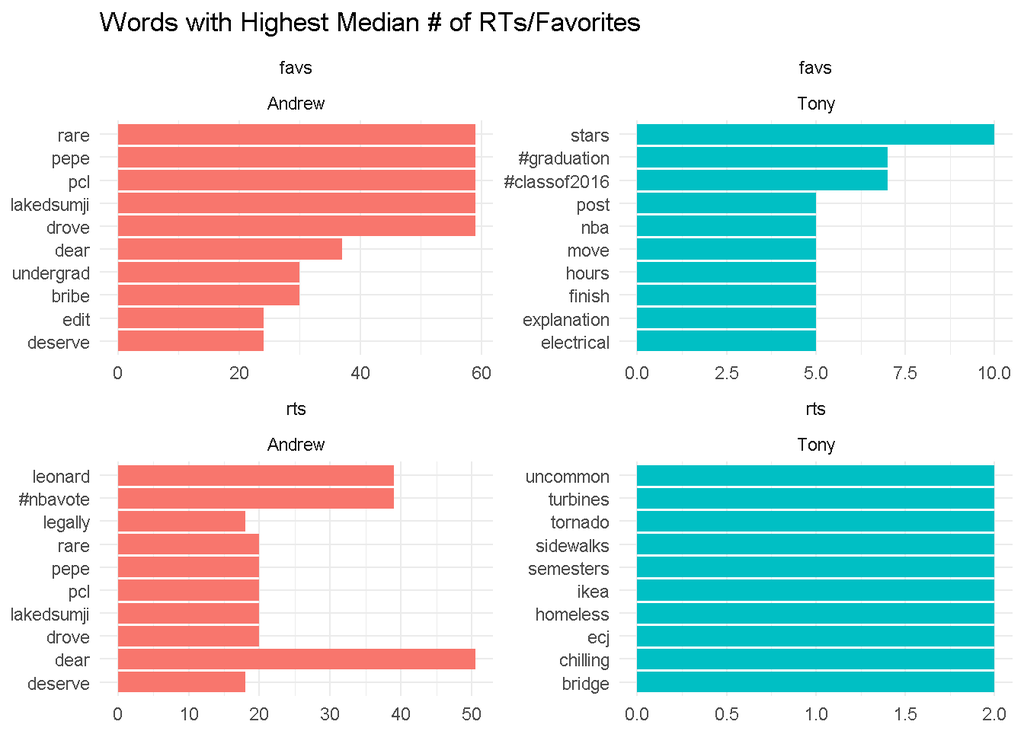

```
## # A tibble: 2 x 10
##   person  uses rts_total favs_total rts_max favs_max rts_avg favs_avg
##    <chr> <int>     <int>      <int>   <dbl>    <dbl>   <dbl>    <dbl>
## 1 Andrew  1148      4414      30412     909      737    3.84    26.49
## 2   Tony   184       131       1025      22       80    0.71     5.57
## # ... with 2 more variables: rts_median <dbl>, favs_median <dbl>
## # A tibble: 2,856 x 4
##    person          word rts_median favs_median
##     <chr>         <chr>      <dbl>       <dbl>
##  1 Andrew           '16        0.0          20
##  2 Andrew           '93        0.0          15
##  3 Andrew            'd        0.0           6
##  4 Andrew           'em        0.5           3
##  5 Andrew       'murica        1.0           5
##  6 Andrew         'twas        3.0          11
##  7 Andrew            #1        0.0           5
##  8 Andrew   #aparnahive        0.0           3
##  9 Andrew   #ballislife        0.0           2
## 10 Andrew #battleof3009        0.0           1
## # ... with 2,846 more rows
## # A tibble: 5,712 x 5
##    person          word  type   calc value
##  *  <chr>         <chr> <chr>  <chr> <dbl>
##  1 Andrew           '16   rts median   0.0
##  2 Andrew           '93   rts median   0.0
##  3 Andrew            'd   rts median   0.0
##  4 Andrew           'em   rts median   0.5
##  5 Andrew       'murica   rts median   1.0
##  6 Andrew         'twas   rts median   3.0
##  7 Andrew            #1   rts median   0.0
##  8 Andrew   #aparnahive   rts median   0.0
##  9 Andrew   #ballislife   rts median   0.0
## 10 Andrew #battleof3009   rts median   0.0
## # ... with 5,702 more rows
```

# Sentiment Analysis

What is the sentiment (i.e. “tone”) of our tweets?

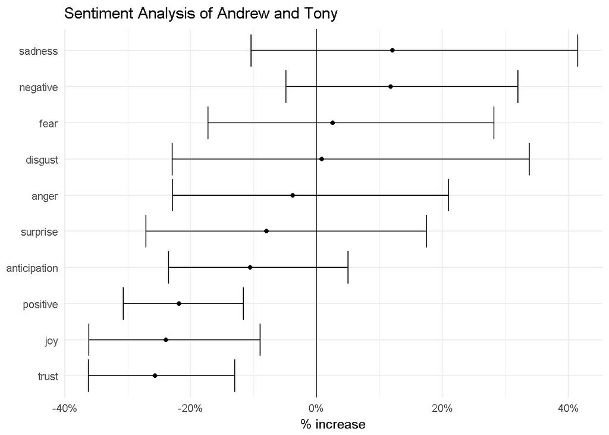

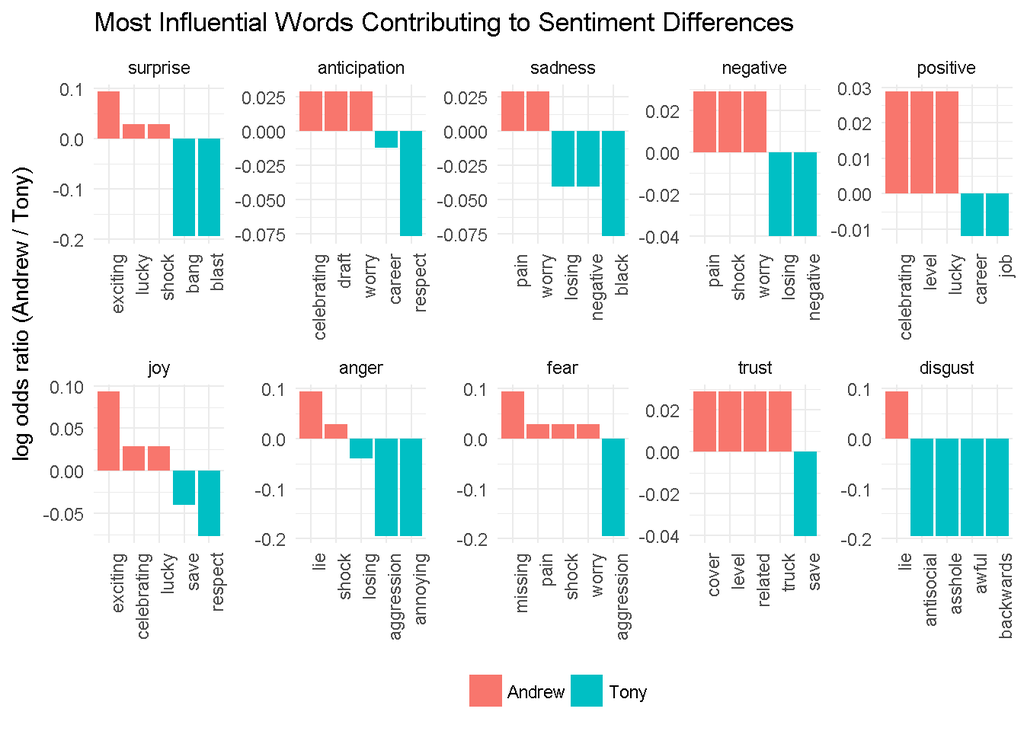

```
## # A tibble: 3,642 x 3
##       status_id person total_words
##           <dbl>  <chr>       <int>
##  1 5.159100e+17 Andrew       17701
##  2 7.594746e+17 Andrew       17701
##  3 8.284065e+17 Andrew       17701
##  4 8.853525e+17 Andrew       17701
##  5 6.700127e+17 Andrew       17701
##  6 7.972158e+17 Andrew       17701
##  7 5.526847e+17 Andrew       17701
##  8 6.892333e+17 Andrew       17701
##  9 7.172034e+17   Tony        3283
## 10 7.114075e+17 Andrew       17701
## # ... with 3,632 more rows
## # A tibble: 20 x 4
```

[output cut: 50 more lines]

# Conclusion

That’s it!